# MEGENA_pipeline

Won-Min Song

October 5, 2016

## MEGENA pipeline as of 10/05/2016

This is a routine MEGENA pipeline description encompassing from data correlation analysis to module plotting, and is based on version 1.3.4-6 https://CRAN.R-project.org/package=MEGENA.Please cite the paper below when MEGENA is applied as part of your analysis:

Song W.-M., Zhang B. (2015) Multiscale Embedded Gene Co-expression Network Analysis. PLoS Comput Biol 11(11): e1004574. doi: 10.1371/journal.pcbi.1004574.

For statistical mechanics aspects involved in MEGENA, please check:

Song W.-M., Di Matteo T.and Aste T., Building Complex Networks with Platonic Solids, Physical Reivew E, 2012 Apr;85(4 Pt 2):046115.

# calculate correlation

```r
rm(list = ls()) # rm R working space

library(MEGENA)

# input parameters
n.cores <- 1; # number of cores/threads to call for PCP
doPar <- FALSE; # do we want to parallelize?
method = "pearson" # method for correlation. either pearson or spearman.
FDR.cutoff = 0.05 # FDR threshold to define significant correlations upon shuffling samples.
module.pval = 0.05 # module significance p-value. Recommended is 0.05.
hub.pval = 0.05 # connectivity significance p-value based random tetrahedral networks
cor.perm = 10; # number of permutations for calculating FDRs for all correlation pairs.
hub.perm = 100; # number of permutations for calculating connectivity significance p-value.

# annotation to be done on the downstream
annot.table=NULL
id.col = 1
symbol.col= 2
###########

data(Sample_Expression) # load toy example data

ijw <- calculate.correlation(datExpr,doPerm = cor.perm)
```

```
## i = 1
## i = 2
## i = 3
## i = 4
## i = 5
## i = 6
## i = 7
## i = 8
## i = 9
## i = 10
## - outputting correlation results...
```

# calculate PFN

In this step, Planar Filtered Network (PFN) is calculated by taking significant correlation pairs, ijw. In the case of utilizing a different similarity measure, one can independently format the results into 3-column data frame with column names c(“row”,“col”,“weight”), and make sure the weight column ranges within 0 to 1. Using this as an input to calculate.PFN() will work just as fine.

```r
#### register multiple cores if needed.
if (doPar & getDoParWorkers() == 1)
{
  set.parallel.backend(num.cores = n.cores)
  # check how many workers are there
  cat(paste("number of cores to use:",getDoParWorkers(),"\n",sep = ""))
}

##### calculate PFN
el <- calculate.PFN(ijw[,1:3],doPar = doPar,num.cores = n.cores)
```

```
## ####### PFN Calculation commences ########
## [1] "PFG is complete."
```

```r
g <- graph.data.frame(el,directed = FALSE)
```

# perform clustering

MCA clustering is performed to identify multiscale clustering analysis. “MEGENA.output”" is the core output to be used in the down-stream analyses for summarization and plotting.

```r
##### perform MCA clustering.
MEGENA.output <- do.MEGENA(g,
 mod.pval = module.pval,hub.pval = hub.pval,remove.unsig = TRUE,
 min.size = 10,max.size = vcount(g)/2,
 doPar = doPar,num.cores = n.cores,n.perm = hub.perm,
 save.output = TRUE)

###### unregister cores as these are not needed anymore.
if (getDoParWorkers() > 1)
{
  env <- foreach:::.foreachGlobals
  rm(list=ls(name=env), pos=env)
}
```

# summarize results

```r
summary.output <- MEGENA.ModuleSummary(MEGENA.output,
    mod.pvalue = module.pval,hub.pvalue = hub.pval,
    min.size = 10,max.size = vcount(g)/2,
    annot.table = annot.table,id.col = id.col,symbol.col = symbol.col,
    output.sig = TRUE)

if (!is.null(annot.table))
{
  # update annotation to map to gene symbols
  V(g)$name <- paste(annot.table[[symbol.col]][match(V(g)$name,annot.table[[id.col]])],V(g)$name,sep = "|")
  summary.output <- output[c("mapped.modules","module.table")]
  names(summary.output)[1] <- "modules"
}

print(head(summary.output$modules,2))
```

```
## $comp1_2
##   [1] "C1QB"         "C1QA"         "SASH3"        "HLA-DPA1"
##   [5] "PLEK"         "NCKAP1L"      "EVI2B"        "HLA-DRA"
##   [9] "FCGR1A"       "CD53"         "PTPRC"        "DOCK2"
##  [13] "ITGB2"        "FCGR1C"       "ARHGAP9"      "CD37"
##  [17] "CD4"          "PTPN7"        "HLA-DMB"      "CD48"
##  [21] "FYB"          "CYBB"         "IKZF1"        "LILRB2"
##  [25] "HLA-DQA1"     "LILRB4"       "IL10RA"       "CCR5"
##  [29] "HLA-DPB1"     "LILRB1"       "CORO1A"       "SPN"
##  [33] "PSTPIP1"      "SNX20"        "MNDA"         "TFEC"
##  [37] "FGL2"         "CD74"         "C1QC"         "ITGAX"
##  [41] "FERMT3"       "CCR1"         "PRKCB"        "CD1E"
##  [45] "HLA-DQB1"     "IL12RB1"      "NCF1C"        "CLEC10A"
##  [49] "FPR3"         "WDFY4"        "SP140"        "FCGR3A"
##  [53] "CTSS"         "BIN2"         "SIGLEC7"      "TLR8"
```

[output cut: 47 more lines]

```r
print(summary.output$module.table)
```

```
##          module.id module.size module.parent
## comp1_2    comp1_2         133       comp1_1
## comp1_3    comp1_3         121       comp1_1
## comp1_4    comp1_4          22       comp1_1
## comp1_5    comp1_5          24       comp1_1
## comp1_6    comp1_6         123       comp1_2
## comp1_8    comp1_8          94       comp1_3
## comp1_10  comp1_10          95       comp1_6
##                                                                             module.hub
## comp1_2  SASH3(34),CD53(33),PTPRC(26),CD86(20),NCKAP1L(19),FERMT3(19),PLEK(18),CD4(16)
## comp1_3                                   CD2(33),CD3E(32),GBP5(20),ITK(19),SLAMF6(18)
## comp1_4                                                                      MS4A1(12)
## comp1_5                                                                      IFIT3(19)
## comp1_6  SASH3(34),CD53(33),PTPRC(26),NCKAP1L(19),FERMT3(19),PLEK(18),CD86(17),CD4(16)
## comp1_8                                            CD3E(32),CD2(32),ITK(19),SLAMF6(18)
## comp1_10           CD53(33),SASH3(29),FERMT3(19),PLEK(18),NCKAP1L(18),CD86(17),CD4(16)
##          module.scale module.pvalue
## comp1_2            S2             0
## comp1_3          <NA>             0
## comp1_4            S2             0
## comp1_5            S2             0
## comp1_6          <NA>             0
## comp1_8            S2             0
## comp1_10           S1             0
```

# Plot some modules

You can generate refined module network plots:

```r
pnet.obj <- plot_module(output = summary.output,PFN = g,subset.module = "comp1_3",
    layout = "kamada.kawai",label.hubs.only = FALSE,
    gene.set = NULL,color.code =  "grey",
    output.plot = FALSE,out.dir = "modulePlot",col.names = c("magenta","green","cyan"),label.scaleFactor = 2,
    hubLabel.col = "black",hubLabel.sizeProp = 1,show.topn.hubs = Inf,show.legend = TRUE)
```

```
## Processing module:comp1_3
##  - # of genes: 121
##  - # of hubs: 5
## - generating module subnetwork figure...
```

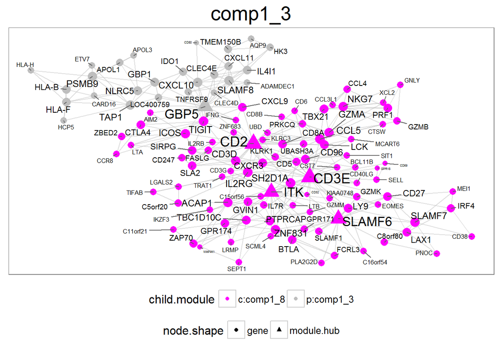

```r
#X11();
print(pnet.obj[[1]])
```